# Comparison SFS plots

n=24 `~/angsd/angsd -out step1_cruentus_ancRef \ -bam /projects/ag-stetter/jdias/data/acc_list/list_cruentus.file.list \ -doSaf 1 \ -GL 2 \ -doMaf 2 \ -doMajorMinor 5 \ -P 24 \ -anc /projects/ag-stetter/jdias/data/genomes/Ahypochondriacus_459_v2.0.fa \ -remove_bads 1 \ -minMapQ 30 \ -minQ 20 \ -minInd 7 \ -SNP_pval 1e-6 \ -skipTriallelic 1`

`~/angsd/misc/realSFS step1.saf.idx -P 4 -fold 1 > folded.sfs`

#### Folded SFS plot generated from angsd , using the maximum likelihood estimate of the SFS using the realSFS (step1 on the Thetas,Tajima,Neutrality tests section)

[figure not shown]

#### Folded SFS plot generated from minor allele frequencies (23 bins)

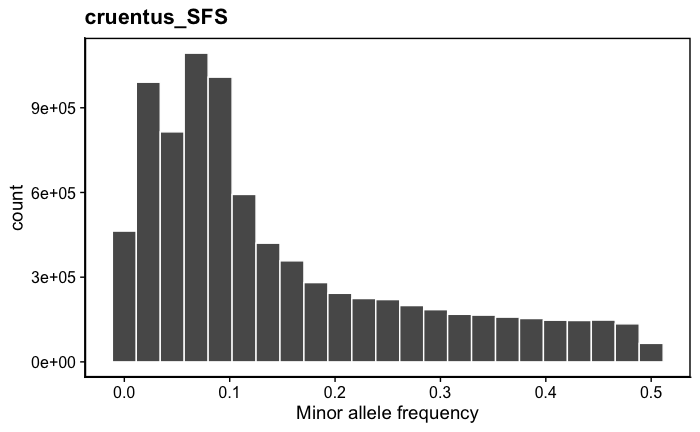

```r
ggplot(cruentus, aes(mAF))+
geom_histogram(bins=23, color='white')+
ggtitle("cruentus_SFS") +
xlab("Minor allele frequency")  +
nice_layout
```

Folded SFS plot generated from minor allele frequencies > 1/24 (23 bins)

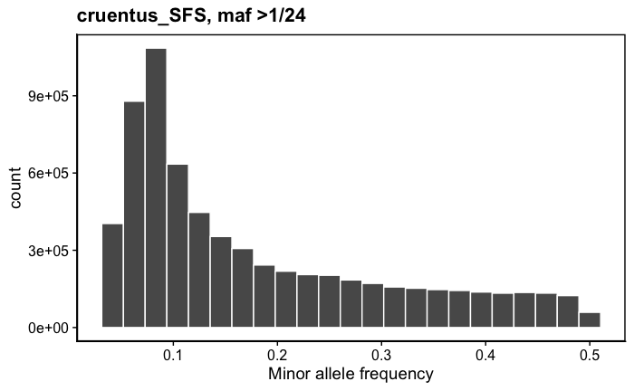

### Total number of sites:

angsd_realSFS: 8381923  
allele frequency estimate: 8382293  
allele frequency estimate (maf >1/24): 6659377

```r
saf2_sfs_cruentus<- scan('/Users/josedias/mount/scratch/jgoncal1/outputs/cruentus_d')
# sfs_cruentus<- sfs_cruentus[-c(1,length(sfs_cruentus))]
 barplot(saf2_sfs_cruentus, names=1:length(sfs_cruentus), main = 'sfs_cruentus')
```

[output not shown]